# Assignment

# Introduction and Summary Brief

Nowadays, the entire United States are facing the racial inequality of law. As we have the incarceration data collected by the Vera Institute, we are able to explore how the situation changed with time and whether the situation is getting better in recent year.

First, let us get a glimpse of the data set. To exclude the missing value and discover recent trends, we chose to study the data generated from 2010 to 2018.

```r
library(tidyverse)
#please set your own dictory
raw_data <- read.csv("incarceration_trends_preded.csv") #We exclude some variables from downloaded file, so please use csv. file we provided
#here we only focus on the time peroid 2010-2018
new_data <- raw_data %>% filter(year>=2010) %>% filter(year<=2018)
#summary
skimr::skim(new_data)
```

Data summary

| Name | new_data |
| --- | --- |
| Number of rows | 28251 |
| Number of columns | 27 |
| _______________________ |  |
| Column type frequency: |  |
| character | 4 |
| numeric | 23 |
| ________________________ |  |
| Group variables | None |

**Variable type: character**

| skim_variable | n_missing | complete_rate | min | max | empty | n_unique | whitespace |
| --- | --- | --- | --- | --- | --- | --- | --- |
| state | 0 | 1 | 2 | 2 | 0 | 51 | 0 |
| county_name | 0 | 1 | 10 | 33 | 0 | 1876 | 0 |
| region | 0 | 1 | 4 | 9 | 0 | 4 | 0 |
| division | 0 | 1 | 7 | 18 | 0 | 9 | 0 |

**Variable type: numeric**

| skim_variable | n_missing | complete_rate | mean | sd | p0 | p25 | p50 | p75 | p100 | hist |
| --- | --- | --- | --- | --- | --- | --- | --- | --- | --- | --- |
| yfips | 0 | 1.00 | 201430367.47 | 258648.98 | 201001001 | 201218174.00 | 201429171.00 | 201645082.00 | 201856045.00 | ▇▇▆▇▇ |
| year | 0 | 1.00 | 2014.00 | 2.58 | 2010 | 2012.00 | 2014.00 | 2016.00 | 2018.00 | ▇▇▃▇▇ |
| fips | 0 | 1.00 | 30367.47 | 15174.55 | 1001 | 18173.00 | 29171.00 | 45083.00 | 56045.00 | ▃▇▆▅▇ |
| total_pop | 0 | 1.00 | 101424.84 | 350033.47 | 0 | 10978.50 | 25693.00 | 67047.50 | 10120540.00 | ▇▁▁▁▁ |
| aapi_pop_15to64 | 0 | 1.00 | 4146.70 | 32505.56 | 0 | 34.00 | 114.00 | 599.00 | 1079927.00 | ▇▁▁▁▁ |
| black_pop_15to64 | 0 | 1.00 | 8897.78 | 42743.09 | 0 | 90.00 | 615.00 | 3864.00 | 1348035.00 | ▇▁▁▁▁ |
| latinx_pop_15to64 | 0 | 1.00 | 11643.78 | 86848.56 | 0 | 198.00 | 641.00 | 2962.00 | 3382603.00 | ▇▁▁▁▁ |
| white_pop_15to64 | 0 | 1.00 | 41996.56 | 102226.38 | 0 | 5085.00 | 12820.00 | 34701.00 | 1968203.00 | ▇▁▁▁▁ |
| commuting_zone | 63 | 1.00 | 277.50 | 189.83 | 1 | 108.00 | 253.00 | 426.00 | 903.00 | ▇▆▅▂▁ |
| total_jail_pop | 1620 | 0.94 | 252.64 | 692.49 | 0 | 28.00 | 80.00 | 212.00 | 19091.94 | ▇▁▁▁▁ |
| aapi_jail_pop | 1638 | 0.94 | 2.64 | 14.56 | 0 | 0.00 | 0.00 | 1.14 | 341.48 | ▇▁▁▁▁ |
| black_jail_pop | 1638 | 0.94 | 88.34 | 321.01 | 0 | 1.62 | 9.50 | 51.50 | 7272.00 | ▇▁▁▁▁ |
| latinx_jail_pop | 1638 | 0.94 | 40.10 | 233.22 | 0 | 1.00 | 3.00 | 12.96 | 9223.12 | ▇▁▁▁▁ |
| white_jail_pop | 1638 | 0.94 | 114.70 | 222.02 | 0 | 15.00 | 47.00 | 124.00 | 5034.00 | ▇▁▁▁▁ |
| total_jail_adm | 2952 | 0.90 | 3948.37 | 9221.65 | 0 | 520.00 | 1352.00 | 3623.04 | 177103.30 | ▇▁▁▁▁ |
| total_jail_pop_rate | 1620 | 0.94 | 579.15 | 1254.87 | 0 | 240.01 | 381.39 | 582.58 | 29109.55 | ▇▁▁▁▁ |
| aapi_jail_pop_rate | 1737 | 0.94 | 629.76 | 4072.39 | 0 | 0.00 | 0.00 | 172.24 | 251730.77 | ▇▁▁▁▁ |
| black_jail_pop_rate | 1671 | 0.94 | 2790.69 | 8279.82 | 0 | 592.59 | 1172.60 | 2329.01 | 300000.00 | ▇▁▁▁▁ |
| latinx_jail_pop_rate | 1638 | 0.94 | 1108.71 | 5054.50 | 0 | 160.40 | 366.88 | 760.06 | 256557.38 | ▇▁▁▁▁ |
| native_jail_pop_rate | 1684 | 0.94 | 1412.74 | 7884.58 | 0 | 0.00 | 0.00 | 723.05 | 296000.00 | ▇▁▁▁▁ |
| white_jail_pop_rate | 1638 | 0.94 | 449.28 | 1391.05 | 0 | 170.94 | 281.68 | 463.90 | 73887.49 | ▇▁▁▁▁ |
| total_jail_adm_rate | 2952 | 0.90 | 8818.83 | 12506.26 | 0 | 4232.74 | 6829.41 | 10364.26 | 434449.36 | ▇▁▁▁▁ |
| total_jail_pretrial_rate | 1746 | 0.94 | 301.45 | 619.88 | 0 | 125.73 | 217.41 | 347.62 | 15507.10 | ▇▁▁▁▁ |

# Expolartory Analysis

Here, we would like to share the answers to those question and analyze the trends behind them.

Which county had the highest total jail admissions rate from 2017-2018?

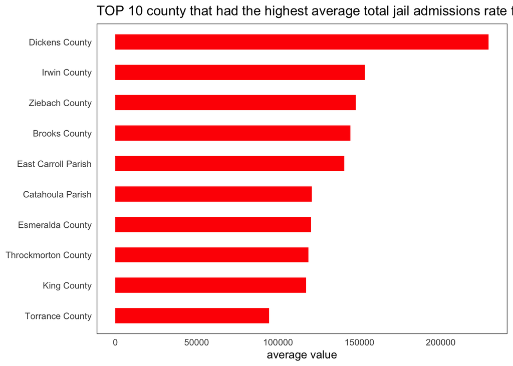

```r
library(ggthemes)
tja <- new_data %>% filter(year>=2017)  %>%
  group_by(county_name) %>%
  summarise(
    Totaladmissions=mean(total_jail_adm_rate,na.rm=T),
  ) %>%
  arrange(desc(Totaladmissions))
top10 <- tja[1:10,]

ggplot(top10) +
  geom_bar(aes(x= Totaladmissions,y = reorder(county_name, Totaladmissions)), width=0.5,stat='identity',fill="red") +
scale_y_discrete(position = "left")+
  theme_bw(base_line_size = 0) +
  labs(title= "TOP 10 county that had the highest average total jail admissions rate from 2017-2018",y = NULL,x="average value")
```

As seen in above figure, recent year those counties had highest average total jail admissions rates. This represents the number (rate) of times people are sent to prison from each county. Obviously, `Dickens County` should be more careful about putting people in prison and develop a robust system of law.

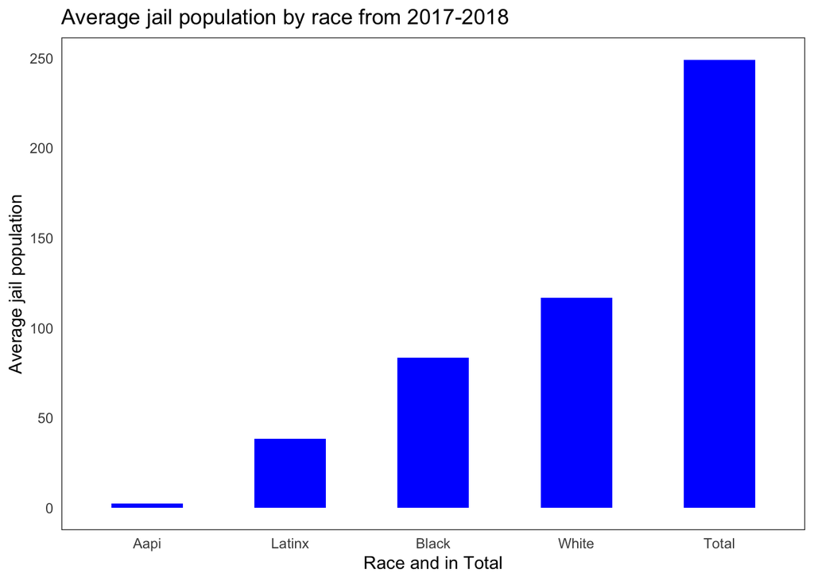

```r
library(reshape2)
rjp <- new_data %>% filter(year==2018)  %>%
  group_by(year) %>%
  summarise(
    Aapi=mean(aapi_jail_pop,na.rm=T),
    Black=mean(black_jail_pop,na.rm=T),
    Latinx=mean(latinx_jail_pop,na.rm=T),
    White=mean(white_jail_pop,na.rm=T),
    Total=mean(total_jail_pop,na.rm=T),
  ) %>%melt(
       id.vars=c("year"),
       variable.name="Race",
       value.name="rjp"
       ) #long format

ggplot(rjp) +
  geom_bar(aes(x= reorder(Race,rjp),y = rjp), width=0.5,stat='identity',fill="blue") +
  theme_bw(base_line_size = 0) +
  labs(title= "Average jail population by race from 2017-2018",y = "Average jail population",x="Race and in Total")
```